# First draft

# Introduction

# Research Questions

We first define a song as “Robotic” if the song is co-written by one of the songwriters we identify as common ghostwriters. This is merely semantic and allows us to say “robotic” instead of “songs written by ghostwriters.”

Our primary research question includes determining linguistic features of lyrics that best differentiate Robotic songs from original songs. Our second research question involves finding differences between Robotic and original songs in general, including lyrical complexity and ranking data.

# Approach

## Data collection

To obtain song names and chart data, we scraped the previous 500 weeks of the Billboard Hot 100 chart. These songs were passed through the Genius API to obtain lyrics, writing credits, and genre. LA Weekly published [an article](https://www.laweekly.com/music/the-20-best-pop-songwriters-in-2017-8763662) that contained 20 prolific songwriters in 2017. We used this list of songwriters as a starting point and eventually added more songwriters by hand.

Stop words were removed in the exploratory and predictive analysis.

## Methods

We utilized several classification algorithms to determine if there exist features that differentiatiate robotic and non-robotic songs. We start with purely lyrical content and end with chart data.

### Naive Bayes

The first model is a modified version of Naive Bayes. Instead of collecting word frequencies, modified Naive Bayes only checks whether a word occurs in a song or not. This was run on a term-document matrix of the lyrics.

```r
convert_count <- function(x) {
  y <- ifelse(x > 0, "Yes", "No")
  y
}
trainNB <- apply(dtm.train, MARGIN = 2, convert_count)
testNB <- apply(dtm.test, MARGIN = 2, convert_count)
classifier <- naiveBayes(trainNB, df.train.lab)
pred <- predict(classifier, testNB)
```

We were able to achieve a 78.46% accuracy rate on the validation set. This is much better than randomly guessing whether a song was robotic or not. We would like to point out our data suffers from a large class imbalance: around 89% of songs was not co-written with a songwriter. Although Naive Bayes was able to achieve an accuracy rate that is better than randomly guessing, it was not able to outperform a simple classifier that predicts “non-Robotic” on every validation sample. Moreover, the specificity rate tells us only 3% of robotic songs were classified correctly.

### Random Forest

```r
#forest <- train(x = as.matrix(dtm.train),
#                y = df.train.lab,
#                method = "rf",
#                ntree = 5,
#                trControl = trainControl(method = "oob"))
#pred <- predict(forest$finalModel, as.matrix(dtm.test))
#conf.mat <- confusionMatrix(pred, df.test.lab)

#conf.mat
```

### LSTM neural network

The last classification algorithm we deployed was a LSTM neural network. If the reader is unfamiliar with LSTM networks, a great introduction is available at [colah’s blog](http://colah.github.io/posts/2015-08-Understanding-LSTMs/). We were only able to achieve an accuracy of 60% on the validation set. However, the specificity rate of 11.2% shows the neural network is able to classify robotic songs better than the previous algorithms.

### Logistic regression

We utilized logisitic regression on the peak position of a song on the Billboard charts and the number of weeks on the chart to predict if a song is robotic or not.

```r
df$Songwriter <- factor(df$Songwriter)
logit <- glm(Songwriter ~ Peak.position + Weeks.on.chart,
             data = df,
             family = "binomial")
summary(logit)
```

```
Call:
glm(formula = Songwriter ~ Peak.position + Weeks.on.chart, family = "binomial",
    data = df)

Deviance Residuals:
    Min       1Q   Median       3Q      Max
-0.7233  -0.5479  -0.4175  -0.3243   2.5412

Coefficients:
                Estimate Std. Error z value Pr(>|z|)
(Intercept)    -1.263006   0.174045  -7.257 3.96e-13 ***
Peak.position  -0.019267   0.002482  -7.762 8.39e-15 ***
Weeks.on.chart  0.001152   0.005557   0.207    0.836
---
Signif. codes:  0 ‘***’ 0.001 ‘**’ 0.01 ‘*’ 0.05 ‘.’ 0.1 ‘ ’ 1

(Dispersion parameter for binomial family taken to be 1)

    Null deviance: 2723.2  on 3897  degrees of freedom
Residual deviance: 2599.4  on 3895  degrees of freedom
AIC: 2605.4

Number of Fisher Scoring iterations: 5
```

## Exploratory

### Sentiment Analysis

For sentiments, we used the (NRC Emotion Lexicon)[https://saifmohammad.com/WebPages/NRC-Emotion-Lexicon.htm]. We run a Poisson test on each sentiment between robotic and non-robotic songs. The 95% confidence intervals are plotted below:

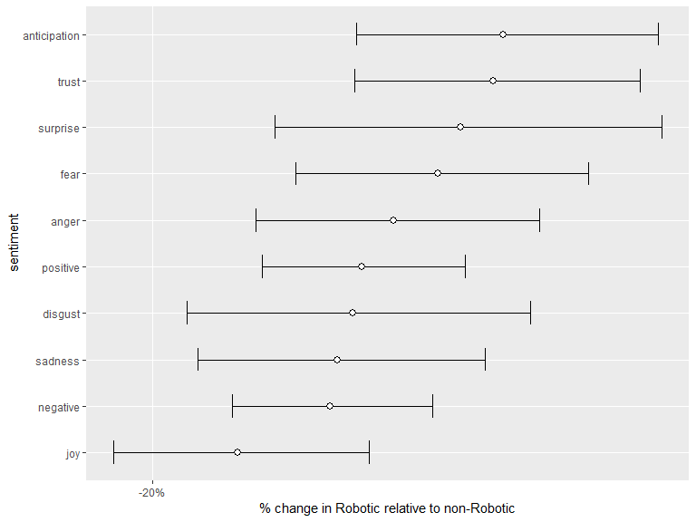

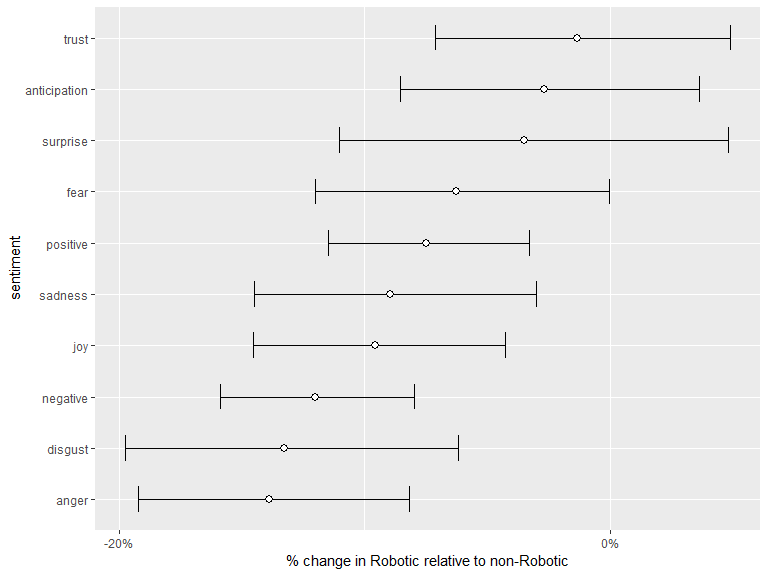

and the rap genre:

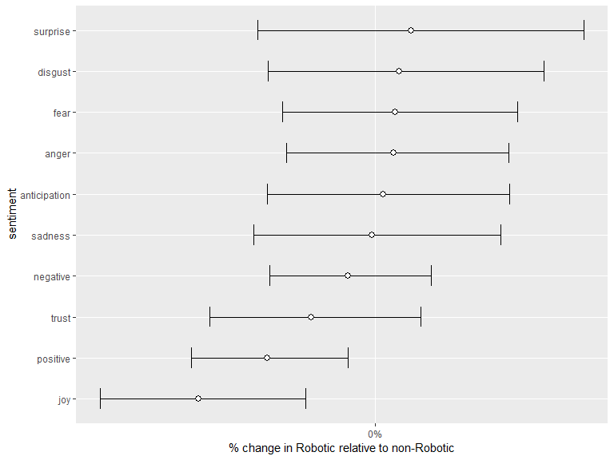

## Latent Dirichlet Allocation

To further explore our dataset for hidden structure, we applied Latent Dirichlet Allocation. We start with two topics. Below is a visualization of words that are most likely to be generated from the respective topic (terms with highest $\beta$):

[output not shown]

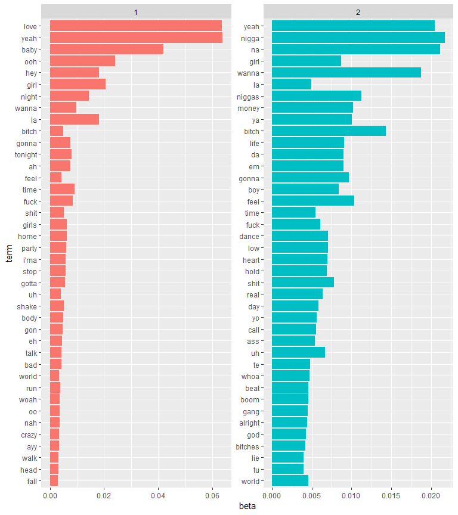

Key takeaways:

- Words most likely to be generated from topic 1 include love, yeah, baby, wanna, la, and ooh. These seem to originate from pop songs.
- In contrast, words most likely to be generated from topic 2 include many expletives, particularly ones in rap songs.

This leads us to believe LDA accurately captures a difference between the language used in pop songs and rap songs.

*confused on how this fits into robotic v non-robotic story*

# Limitations

## From Genius

We may have picked up lyrics of covers and remixes instead of the original lyrics.

## Lyrical ranking

Define justifiable metric(s) for “lyrical complexity”

# Future work

- Would like to utilize musical markers instead of just lyrics
- Would like to delve into the change of artists’ success over time